# W_UP_01

eren rosenfeld

fall 2021

# Introduction

Create an Rstudio project in your shared space on rstudio.cloud. Using the dataset called pushups from the tigerstats package in R; answer the question posed by this null and alternate hypothesis in an html markdown document.

$H_0$: There is no difference between the average number of pushups of line vs skill players

$H_A$: The average number of pushups done by line players is statistically different than that of skill players.

# Results

## Descriptive Results

### Graphical Descriptive Results

### Plot boxplots

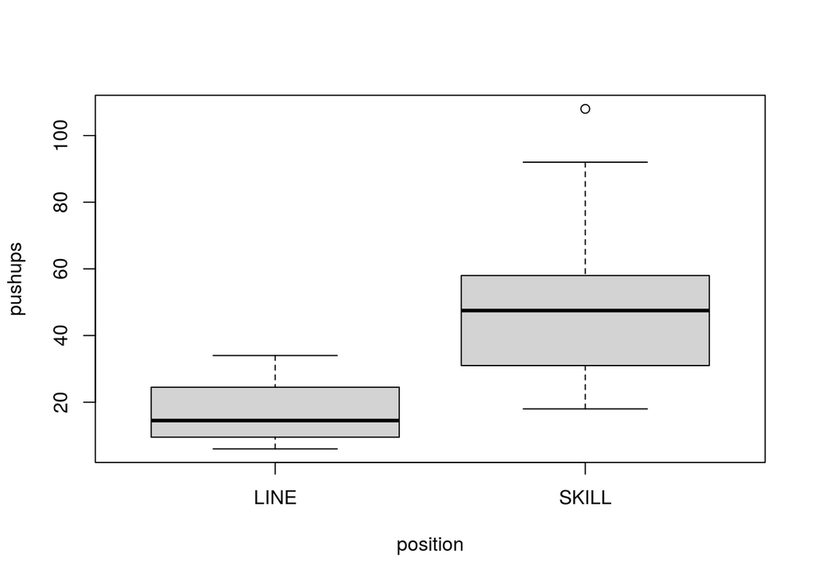

```r
boxplot(pushups~position,data=mydata)
```

# Numerical results

```r
favstats(pushups~position,data=mydata)
```

```
##   position min    Q1 median    Q3 max     mean        sd  n missing
## 1     LINE   6 10.25   14.5 24.25  34 17.12500  9.745878  8       0
## 2    SKILL  18 31.25   47.5 57.50 108 49.72727 23.036579 22       0
```

## Inferential Results

```r
t.test(pushups~position,data=mydata)
```

```
##
##  Welch Two Sample t-test
##
## data:  pushups by position
## t = -5.4341, df = 27.079, p-value = 9.421e-06
## alternative hypothesis: true difference in means between group LINE and group SKILL is not equal to 0
## 95 percent confidence interval:
##  -44.91068 -20.29387
## sample estimates:
##  mean in group LINE mean in group SKILL
##            17.12500            49.72727
```

The original question was is there a difference in the average number of pushups that skill players and line players can do. We did a box plot to show the differences. We did a numerical summary to get the averages. The skill players can do more pushups on average in 2 minutes than can line players.